# Logistic Regression

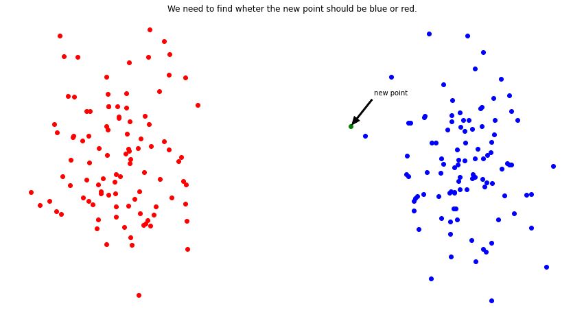

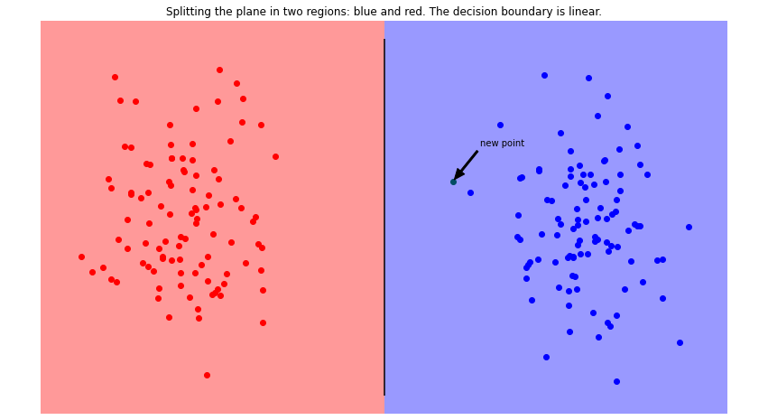

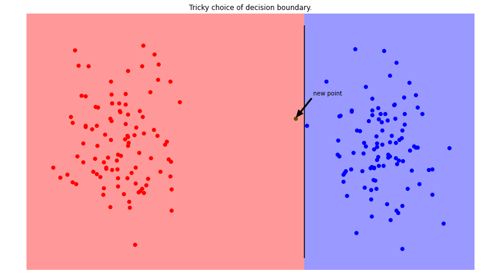

## Let's define loss function

$$ Loss = \sum_{datapoint\ \in\ \text{misclassified datapoints}} distance(datapoint, line)$$

## Perceptron (we can talk about this later)

### Consider two class case

\begin{eqnarray*} p(C_1 | \phi) &\mathop{=}^{def}& y(\phi) \mathop{=}^{def} \sigma(w^T\phi) \\ P(C_2 | \phi) &=& 1 - p (C_1 | \phi) \end{eqnarray*}

$$\sigma(x) = \frac{1}{1 + e^{-x}}$$

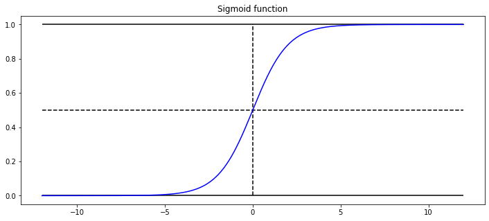

$$\frac{d\sigma}{d\alpha} = \sigma\cdot(1-\sigma)$$$$$$$$\sigma(- \alpha) = 1 - \sigma(\alpha)$$

Given $\{ \phi_n, t_n \}$, where $\phi_n$ is feature vector of $n$-th datapoint, and $t_n$ is 1, if datapoint is from $C_1$ class and 0 otherwise.

$$Likelihood = P(t| \phi, w) = \prod_{n=1}^N P(t_n |\phi_n, w) = \prod_{n=1}^N y_n^{t_n} (1 - y_n)^{1-t_n}$$

$$ Loss(w) = -Log Likelihood = -\sum_{n=1}^N t_n\ ln(y_n) + (1 - t_n)\ ln(1 - y_n)$$

$$\nabla Loss(w) = -\sum_{n=1}^N t_n\ (1-y_n) \phi_n - (1 - t_n)\ y_n \phi_n = \sum_{n=1}^N (y_n - t_n) \phi_n$$

$$\frac{d\sigma}{d\alpha} = \sigma\cdot(1-\sigma)$$$$$$$$\frac{d ln\sigma(\alpha)}{d\alpha} = 1 - \sigma$$

## Probabilistic View

### Two class case

\begin{eqnarray*} p(C_1 | \phi) &=& \frac{p(\phi | C_1) \cdot p(C_1)}{p(\phi)} &=& \frac{p(\phi | C_1) \cdot p(C_1)}{p(\phi| C_1)\cdot p(C_1) + p(\phi| C_2)\cdot p(C_2)} \\ \\ &=& \frac{1}{1 + \frac{p(\phi| C_2)\cdot p(C_2)}{p(\phi| C_1)\cdot p(C_1)}} &=& \frac{1}{1 + exp(-\alpha)} = \sigma(\alpha) \end{eqnarray*}

Where

$$\alpha = \ln\frac{p(\phi| C_1)\cdot p(C_1)}{p(\phi| C_2)\cdot p(C_2)}$$

### Multiple class case

\begin{eqnarray*} p(C_k | \phi) &=& \frac{p(\phi | C_k) \cdot p(C_k)}{p(\phi)} &=& \frac{p(\phi | C_k) \cdot p(C_k)}{\sum_{i=1}^m p(\phi | C_i) \cdot p(C_i)} \\ \\ &=& \frac{exp(\alpha_k)}{\sum_{i=1}^m exp(\alpha_i)} \end{eqnarray*}

Where

$$\alpha_k = \ln p(\phi| C_k) \cdot p(C_k)$$

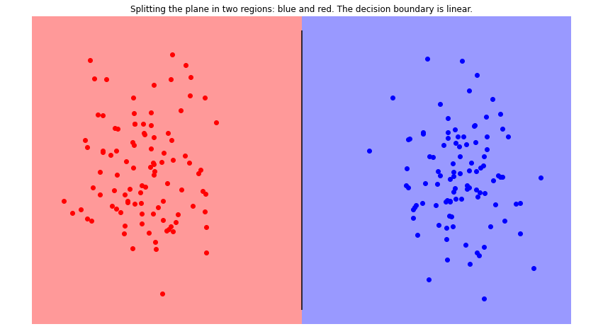

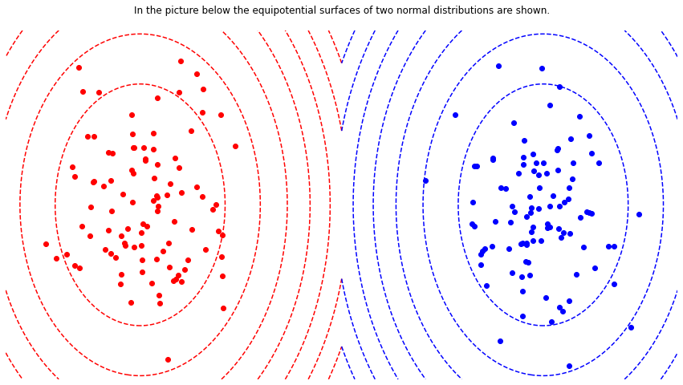

Consider gaussian classes:

$$p(\phi|C_k) = \frac{1}{(2\pi)^{D/2}}\frac{1}{|\Sigma|^{1/2}}exp[-\frac{1}{2}(\phi-\mu_k)^T\Sigma^{-1}(\phi-\mu_k)]$$

Note: Covariance matrix is the same for all classes.

Let's find decision boundaries between classes.

## Two classes case

$$p(C_1 | \phi) = \sigma(\alpha)$$$$\alpha = \ln\frac{p(\phi|C_1)p(C_1)}{p(\phi|C_2)p(C_2)}$$

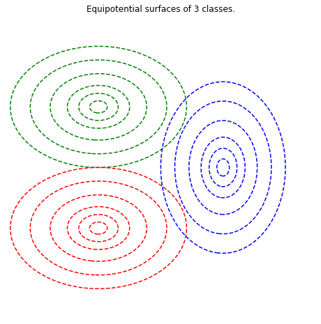

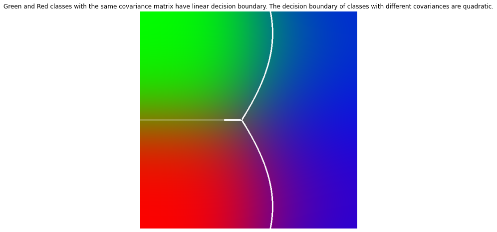

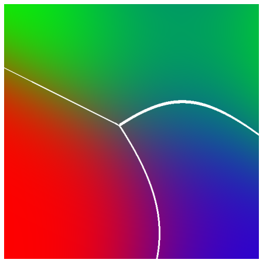

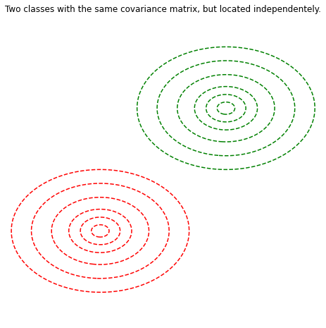

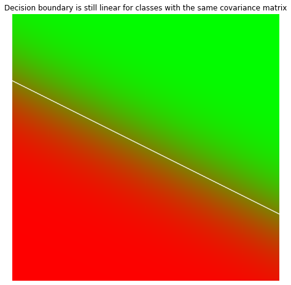

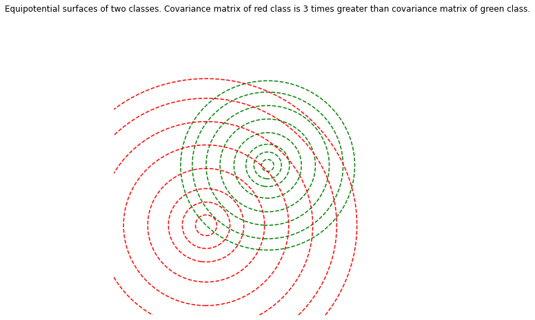

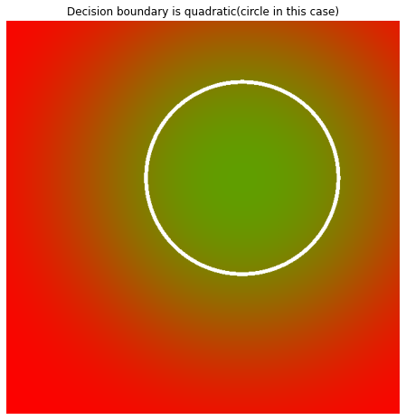